# Nb_CMV

Bibechana Paudel

2025-09-28

# Library used

```r
#install.packages("tidyverse")
#install.packages("ggplot2")
#install.packages("agricolae")
#install.packages("tidyr")
#install.packages("ggpubr")
#install.packages("multcomp")
#install.packages("emmeans")
#install.packages("multcompView")
library(tidyverse)
library(ggplot2)
library(agricolae)
library(tidyr)
library(ggpubr)
library(multcomp)
library(emmeans)
library(multcompView)
```

# **First trial**

## Load the data

```r
rep1 <- read.csv("Data-obj1-New/Nb_CMV_1st_trial_New.csv", header=T)
head(rep1)  # View the first few rows
```

```
##    Dpi Rep    Cq
## 1 IL-1   1 24.53
## 2 IL-1   2 24.67
## 3 IL-1   3 24.68
## 4 IL-4   1 14.24
## 5 IL-4   2 14.24
## 6 IL-4   3 14.34
```

```r
str(rep1)   # Check the structure of the data
```

```
## 'data.frame':    18 obs. of  3 variables:
##  $ Dpi: chr  "IL-1" "IL-1" "IL-1" "IL-4" ...
##  $ Rep: int  1 2 3 1 2 3 1 2 3 1 ...
##  $ Cq : num  24.5 24.7 24.7 14.2 14.2 ...
```

```r
summary(rep1) # Quick statistical summary
```

```
##      Dpi                 Rep          Cq
##  Length:18          Min.   :1   Min.   :12.47
##  Class :character   1st Qu.:1   1st Qu.:13.10
##  Mode  :character   Median :2   Median :18.89
##                     Mean   :2   Mean   :18.96
##                     3rd Qu.:3   3rd Qu.:24.64
##                     Max.   :3   Max.   :25.56
```

###Make the factor variable

```r
rep1$Dpi<-as.factor(rep1$Dpi)
```

## Viralload

##Calculate the ViralLoad using the regression equation derived by (Feng , J.L et al., 2006 ) and log transform for normality.

[Feng, J.L et al., 2006](https://academic.oup.com/abbs/article/38/10/669/217)

```r
rep1<-rep1 %>%
mutate (ViralLoad=((10^((Cq-37.416)/-3.353)))) %>% ##added a new column and named ViralLoad
mutate(logViralLoad=log10(ViralLoad))  ##added a new column and named logViralLoad
```

##Classify the sample collection days based on leaf

```r
rep1$Leaf_sample<- ifelse(
  grepl("^IL", rep1$Dpi), "Inoculated",  # Matches Dpi values starting with IL
  ifelse(grepl("^SL", rep1$Dpi), "Systemic", NA)
)
```

##Data summarization

```r
CMV1 <- rep1 %>%  # Start with the dataset `rep1` and pipe (%>%) it into the next operations
  group_by(Dpi, Leaf_sample) %>%   # Group the data by treatment type and days post-inoculation (Dpi)
  dplyr::summarize(
    avg.virus= mean(logViralLoad, na.rm=TRUE),
    n=n(),
    se = sd(logViralLoad)/sqrt(n)) # join the significant letters with the PVY1 data frame.
```

[output not shown]

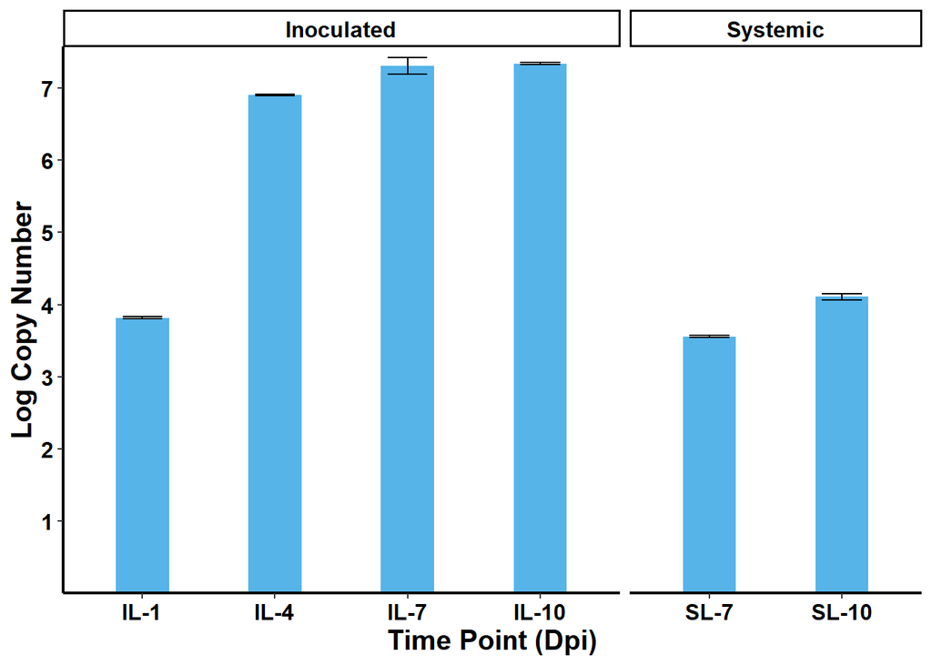

```r
CMV_1 <- ggplot(CMV1,aes(x =factor(Dpi,levels=c("IL-1", "IL-4", "IL-7", "IL-10","SL-7", "SL-10")), y = avg.virus)) +
  stat_summary(fun=mean,geom="bar", position = position_dodge(width = 0.3), width = 0.4, fill="#56B4E9") +
   geom_errorbar(aes(ymin = avg.virus - se,
                    ymax = avg.virus + se),
                width = 0.3,
                position = position_dodge(width = 0.3)) +
  labs(x = "Time Point (Dpi)", y = "Log Copy Number") +
  theme_classic() +
  theme(plot.title = element_text(hjust = 0.5),
        strip.text = element_text(face = "bold", size = 12, color = "black"),
        legend.position = "none",
        axis.text.x = element_text(color = "black", face="bold", size=12),   # X-axis text color
        axis.text.y = element_text(color = "black", face="bold", size=12),   # Y-axis text color
        axis.title.x = element_text(color = "black", face="bold", size=15),  # X-axis label color
        axis.title.y = element_text(color = "black", face="bold", size=15),  # Y-axis label color
        axis.line = element_line(color = "black", size=0.75)      # Axis lines color
  ) +
  scale_y_continuous(
    expand = expansion(mult = c(0, 0.02)), breaks = seq(1, 9, by = 1)  # This removes padding at the bottom of the plot
  )+
   scale_x_discrete(drop = TRUE) +
  facet_grid(~Leaf_sample, scale="free_x", space="free_x")
  # Sets y-axis limits but removes points outside 0-8

CMV_1
```

# **Second trial**

## Load the data

```r
rep2 <- read.csv("Data-obj1-New/Nb_CMV_2nd_trial_New.csv", header=T)
head(rep2)  # View the first few rows
```

```
##    Dpi Rep    Cq
## 1 IL-1   1 18.90
## 2 IL-1   2 19.05
## 3 IL-1   3 18.94
## 4 IL-4   1 13.17
## 5 IL-4   2 13.25
## 6 IL-4   3 13.31
```

```r
str(rep2)   # Check the structure of the data
```

```
## 'data.frame':    21 obs. of  3 variables:
##  $ Dpi: chr  "IL-1" "IL-1" "IL-1" "IL-4" ...
##  $ Rep: int  1 2 3 1 2 3 1 2 3 1 ...
##  $ Cq : num  18.9 19.1 18.9 13.2 13.2 ...
```

```r
summary(rep2) # Quick statistical summary
```

```
##      Dpi                 Rep          Cq
##  Length:21          Min.   :1   Min.   :11.87
##  Class :character   1st Qu.:1   1st Qu.:12.90
##  Mode  :character   Median :2   Median :13.17
##                     Mean   :2   Mean   :16.05
##                     3rd Qu.:3   3rd Qu.:18.90
##                     Max.   :3   Max.   :29.22
```

###Make the factor variable

```r
rep2$Dpi<-as.factor(rep2$Dpi)
```

## Viral load

##Calculate the ViralLoad using the regression equation derived by (Feng , J.L et al., 2006 ) and log transform for normality.

[Feng, J.L et al., 2006](https://academic.oup.com/abbs/article/38/10/669/217)

```r
rep2<-rep2 %>%
mutate (ViralLoad=((10^((Cq-37.416)/-3.353)))) %>% ##added a new column and named ViralLoad
mutate(logViralLoad=log10(ViralLoad)) %>%
  filter(Dpi!="SL-14")##added a new column and named logViralLoad
```

##Classify the sample collection days based on leaf

```r
rep2$Leaf_sample<-ifelse(
  grepl("^IL", rep2$Dpi), "Inoculated",  # Matches Dpi values starting with IL
  ifelse(grepl("^SL", rep2$Dpi), "Systemic", NA))
```

##Data summarization

```r
CMV2 <- rep2 %>%  # Start with the dataset `rep2` and pipe (%>%) it into the next operations
  group_by(Dpi, Leaf_sample) %>%   # Group the data by treatment type and days post-inoculation (Dpi)
  dplyr::summarize(
    avg.virus= mean(logViralLoad, na.rm=TRUE),
    n=n(),
    se = sd(logViralLoad)/sqrt(n)) # join the significant letters with the PVY1 data frame.
```

[output not shown]

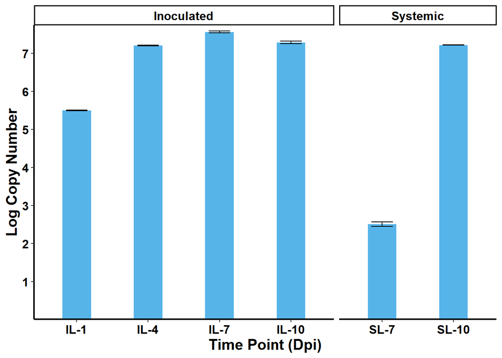

```r
CMV_2 <- ggplot(CMV2,aes(x =factor(Dpi,levels=c("IL-1", "IL-4", "IL-7", "IL-10","SL-7", "SL-10")), y = avg.virus)) +
  stat_summary(fun=mean,geom="bar", position = position_dodge(width = 0.3), width = 0.4, fill="#56B4E9") +
   geom_errorbar(aes(ymin = avg.virus - se,
                    ymax = avg.virus + se),
                width = 0.3,
                position = position_dodge(width = 0.3)) +
  labs(x = "Time Point (Dpi)", y = "Log Copy Number") +
  theme_classic() +
  theme(plot.title = element_text(hjust = 0.5),
        strip.text = element_text(face = "bold", size = 12, color = "black"),
        legend.position = "none",
        axis.text.x = element_text(color = "black", face="bold", size=12),   # X-axis text color
        axis.text.y = element_text(color = "black", face="bold", size=12),   # Y-axis text color
        axis.title.x = element_text(color = "black", face="bold", size=15),  # X-axis label color
        axis.title.y = element_text(color = "black", face="bold", size=15),  # Y-axis label color
        axis.line = element_line(color = "black", size=0.75)      # Axis lines color
  ) +
  scale_y_continuous(
    expand = expansion(mult = c(0, 0.02)), breaks = seq(1, 9, by = 1)  # This removes padding at the bottom of the plot
  )+
   scale_x_discrete(drop = TRUE) +
  facet_grid(~Leaf_sample, scale="free_x", space="free_x")
 # Sets y-axis limits but removes points outside 0-8
# Sets y-axis limits but removes points outside 0-8

CMV_2
```

# **Supplementary First trial**

## Load the data

```r
rep1_RNA3_10ng <- read.csv("Data-obj1-New/Nb_CMV_1st_RNA3_10ng.csv", header=T)
head(rep1_RNA3_10ng)  # View the first few rows
```

```
##    Dpi Rep    Cq
## 1 IL-1   1 19.38
## 2 IL-1   2 19.06
## 3 IL-1   3 19.17
## 4 IL-4   1  8.59
## 5 IL-4   2  8.26
## 6 IL-4   3  8.39
```

```r
str(rep1_RNA3_10ng)   # Check the structure of the data
```

[output not shown]

```r
summary(rep1_RNA3_10ng) # Quick statistical summary
```

```
##      Dpi                 Rep          Cq
##  Length:18          Min.   :1   Min.   : 6.02
##  Class :character   1st Qu.:1   1st Qu.: 6.22
##  Mode  :character   Median :2   Median :13.82
##                     Mean   :2   Mean   :13.21
##                     3rd Qu.:3   3rd Qu.:19.33
##                     Max.   :3   Max.   :20.09
```

###Make the factor variable

```r
rep1_RNA3_10ng$Dpi<-as.factor(rep1_RNA3_10ng$Dpi)
```

## Viral load

##Calculate the ViralLoad using the regression equation derived by (Feng , J.L et al., 2006 ) and log transform for normality.

[Feng, J.L et al., 2006](https://academic.oup.com/abbs/article/38/10/669/217)

```r
rep1_RNA3_10ng<-rep1_RNA3_10ng %>%
mutate (ViralLoad=((10^((Cq-37.416)/-3.353)))) %>% ##added a new column and named ViralLoad
mutate(logViralLoad=log10(ViralLoad))  ##added a new column and named logViralLoad
```

##Classify the sample collection days based on leaf

```r
rep1_RNA3_10ng$Leaf_sample<- ifelse(
  grepl("^IL", rep1_RNA3_10ng$Dpi), "Inoculated",  # Matches Dpi values starting with IL
  ifelse(grepl("^SL", rep1_RNA3_10ng$Dpi), "Systemic", NA)
)
```

##Data summarization

```r
CMV1 <- rep1_RNA3_10ng %>%  # Start with the dataset `rep1` and pipe (%>%) it into the next operations
  group_by(Dpi, Leaf_sample) %>%   # Group the data by treatment type and days post-inoculation (Dpi)
  dplyr::summarize(
    avg.virus= mean(logViralLoad, na.rm=TRUE),
    n=n(),
    se = sd(logViralLoad)/sqrt(n)) # join the significant letters with the PVY1 data frame.
```

[output not shown]

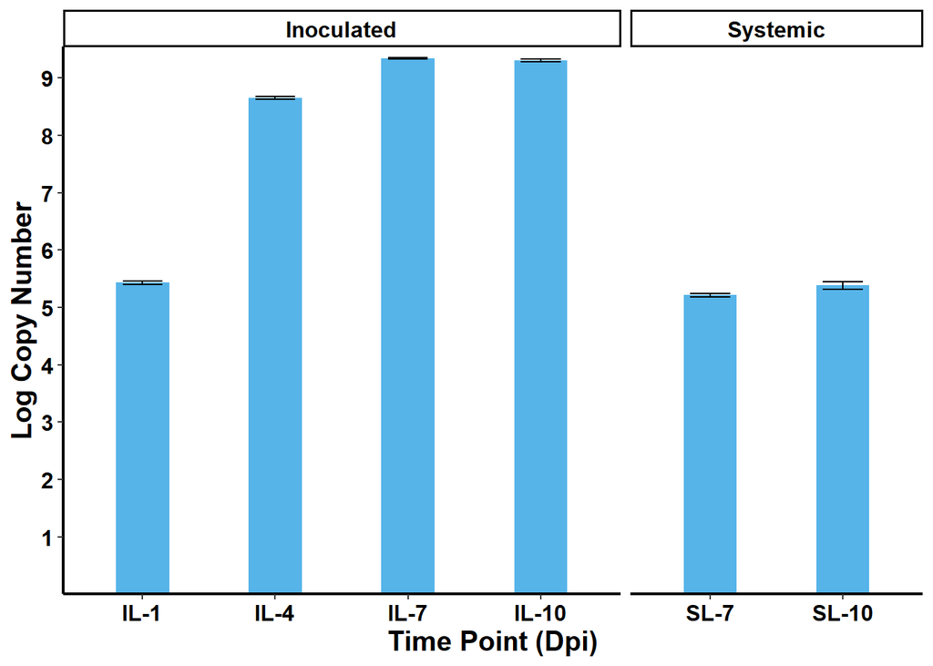

```r
CMV_1_RNA3_10ng <- ggplot(CMV1,aes(x =factor(Dpi,levels=c("IL-1", "IL-4", "IL-7", "IL-10","SL-7", "SL-10")), y = avg.virus)) +
  stat_summary(fun=mean,geom="bar", position = position_dodge(width = 0.3), width = 0.4, fill="#56B4E9") +
   geom_errorbar(aes(ymin = avg.virus - se,
                    ymax = avg.virus + se),
                width = 0.3,
                position = position_dodge(width = 0.3)) +
  labs(x = "Time Point (Dpi)", y = "Log Copy Number") +
  theme_classic() +
  theme(plot.title = element_text(hjust = 0.5),
        strip.text = element_text(face = "bold", size = 12, color = "black"),
        legend.position = "none",
        axis.text.x = element_text(color = "black", face="bold", size=12),   # X-axis text color
        axis.text.y = element_text(color = "black", face="bold", size=12),   # Y-axis text color
        axis.title.x = element_text(color = "black", face="bold", size=15),  # X-axis label color
        axis.title.y = element_text(color = "black", face="bold", size=15),  # Y-axis label color
        axis.line = element_line(color = "black", size=0.75)      # Axis lines color
  ) +
  scale_y_continuous(
    expand = expansion(mult = c(0, 0.02)), breaks = seq(1, 9, by = 1)  # This removes padding at the bottom of the plot
  )+
   scale_x_discrete(drop = TRUE) +
  facet_grid(~Leaf_sample, scale="free_x", space="free_x")
 # Sets y-axis limits but removes points outside 0-8

CMV_1_RNA3_10ng
```

## RNA3_NB

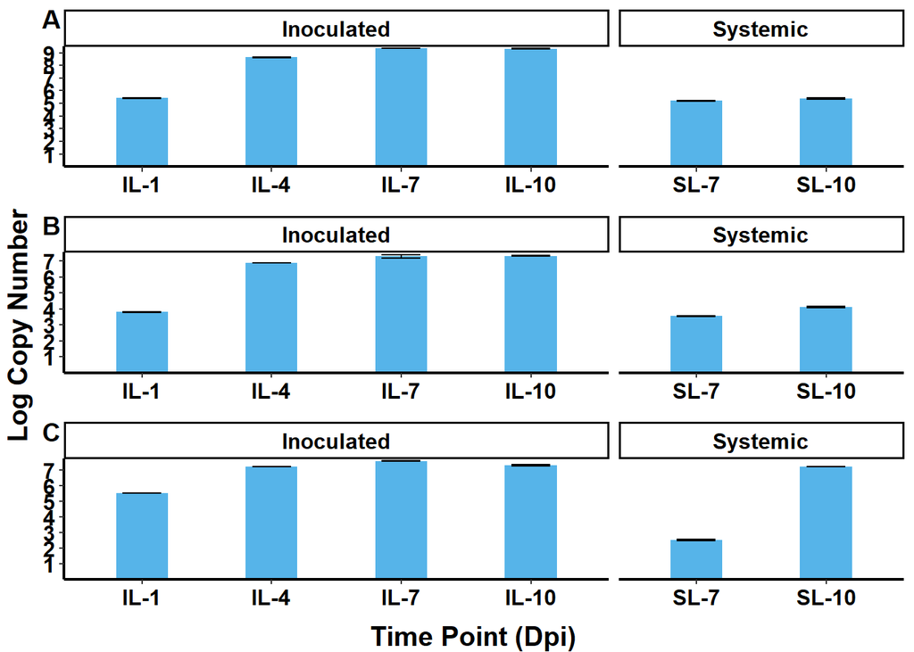

```r
CMV_1_RNA3_10ng <- CMV_1_RNA3_10ng +
  labs(x = NULL, y = NULL) + # Remove axis labels
  theme(axis.title = element_blank()) # Remove axis titles

CMV_1 <- CMV_1 +
  labs(x = NULL, y = NULL) +
  theme(axis.title = element_blank())

CMV_2 <- CMV_2 +
  labs(x = NULL, y = NULL) +
  theme(axis.title = element_blank())
# Combine the three modified plots into one figure
combined_plot_RNA3 <- ggarrange(
  CMV_1_RNA3_10ng,
  CMV_1,
  CMV_2,
  ncol = 1,
  labels = c("A", "B", "C"), # Add labels A, B, C
  align = "v"      # vertically align plots
)

# Add shared axis titles
combined_plot_RNA3_annotated <- annotate_figure(
  combined_plot_RNA3,
  bottom = text_grob("Time Point (Dpi)", size = 15, face="bold"),
  left = text_grob("Log Copy Number", rot = 90, size = 15, face="bold")
)
combined_plot_RNA3_annotated
```

### Load the data

```r
rep1_CP_10ng <- read.csv("Data-obj1-New/Nb_CMV_1st_CP_10ng.csv", header=T)
head(rep1_CP_10ng)  # View the first few rows
```

```
##    Dpi Rep    Cq
## 1 IL-1   1 27.01
## 2 IL-1   2 27.14
## 3 IL-1   3 26.89
## 4 IL-4   1 18.82
## 5 IL-4   2 18.08
## 6 IL-4   3 18.08
```

```r
str(rep1_CP_10ng)   # Check the structure of the data
```

```
## 'data.frame':    18 obs. of  3 variables:
##  $ Dpi: chr  "IL-1" "IL-1" "IL-1" "IL-4" ...
##  $ Rep: int  1 2 3 1 2 3 1 2 3 1 ...
##  $ Cq : num  27 27.1 26.9 18.8 18.1 ...
```

```r
summary(rep1_CP_10ng) # Quick statistical summary
```

```
##      Dpi                 Rep          Cq
##  Length:18          Min.   :1   Min.   :15.97
##  Class :character   1st Qu.:1   1st Qu.:16.16
##  Mode  :character   Median :2   Median :22.86
##                     Mean   :2   Mean   :22.43
##                     3rd Qu.:3   3rd Qu.:28.18
##                     Max.   :3   Max.   :29.01
```

###Make the factor variable

```r
rep1_CP_10ng$Dpi<-as.factor(rep1_CP_10ng$Dpi)
```

## Viral load

##Calculate the ViralLoad using the regression equation derived by (Feng , J.L et al., 2006 ) and log transform for normality.

[Feng, J.L et al., 2006](https://academic.oup.com/abbs/article/38/10/669/217)

```r
rep1_CP_10ng<-rep1_CP_10ng %>%
mutate (ViralLoad=((10^((Cq-37.416)/-3.353)))) %>% ##added a new column and named ViralLoad
mutate(logViralLoad=log10(ViralLoad))  ##added a new column and named logViralLoad
```

##Classify the sample collection days based on leaf

```r
rep1_CP_10ng$Leaf_sample<- ifelse(
  grepl("^IL", rep1_CP_10ng$Dpi), "Inoculated",  # Matches Dpi values starting with IL
  ifelse(grepl("^SL", rep1_CP_10ng$Dpi), "Systemic", NA)
)
```

##Data summarization

```r
CMV1 <- rep1_CP_10ng %>%  # Start with the dataset `rep1` and pipe (%>%) it into the next operations
  group_by(Dpi, Leaf_sample) %>%   # Group the data by treatment type and days post-inoculation (Dpi)
  dplyr::summarize(
    avg.virus= mean(logViralLoad, na.rm=TRUE),
    n=n(),
    se = sd(logViralLoad)/sqrt(n)) # join the significant letters with the PVY1 data frame.
```

[output not shown]

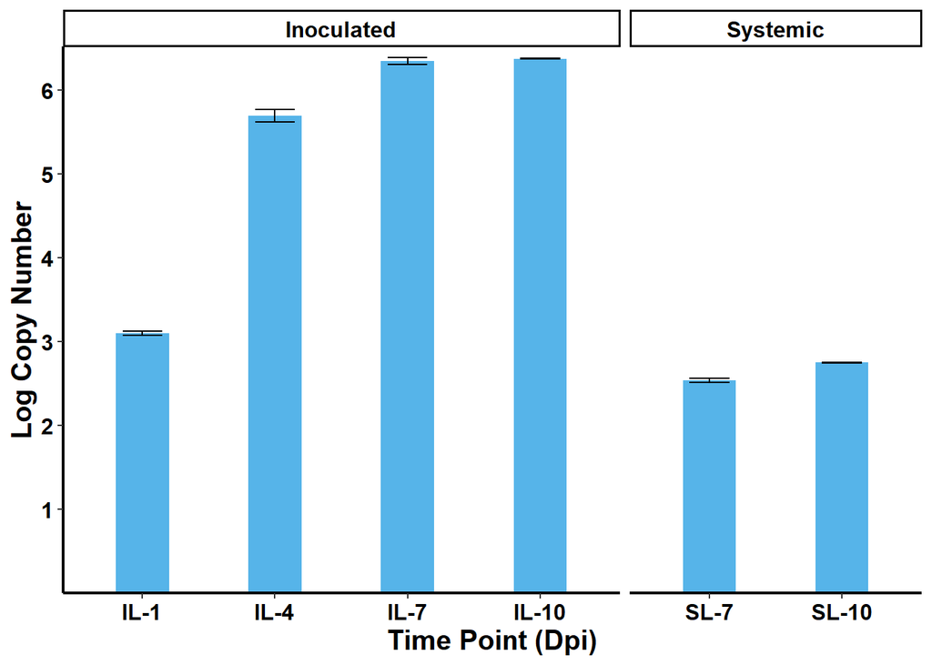

```r
CMV_1_CP_10ng <- ggplot(CMV1,aes(x =factor(Dpi,levels=c("IL-1", "IL-4", "IL-7", "IL-10","SL-7", "SL-10")), y = avg.virus)) +
  stat_summary(fun=mean,geom="bar", position = position_dodge(width = 0.3), width = 0.4, fill="#56B4E9") +
   geom_errorbar(aes(ymin = avg.virus - se,
                    ymax = avg.virus + se),
                width = 0.3,
                position = position_dodge(width = 0.3)) +
  labs(x = "Time Point (Dpi)", y = "Log Copy Number") +
  theme_classic() +
  theme(plot.title = element_text(hjust = 0.5),
        strip.text = element_text(face = "bold", size = 12, color = "black"),
        legend.position = "none",
        axis.text.x = element_text(color = "black", face="bold", size=12),   # X-axis text color
        axis.text.y = element_text(color = "black", face="bold", size=12),   # Y-axis text color
        axis.title.x = element_text(color = "black", face="bold", size=15),  # X-axis label color
        axis.title.y = element_text(color = "black", face="bold", size=15),  # Y-axis label color
        axis.line = element_line(color = "black", size=0.75)      # Axis lines color
  ) +
  scale_y_continuous(
    expand = expansion(mult = c(0, 0.02)), breaks = seq(1, 9, by = 1)  # This removes padding at the bottom of the plot
  )+
   scale_x_discrete(drop = TRUE) +
  facet_grid(~Leaf_sample, scale="free_x", space="free_x")# Sets y-axis limits but removes points outside 0-8

CMV_1_CP_10ng
```

## Load the data

```r
rep1_CP_1ng <- read.csv("Data-obj1-New/Nb_CMV_1st_CP_1ng.csv", header=T)
head(rep1_CP_1ng)  # View the first few rows
```

```
##    Dpi Rep    Cq
## 1 IL-1   1 30.98
## 2 IL-1   2 31.17
## 3 IL-1   3 31.21
## 4 IL-4   1 23.20
## 5 IL-4   2 23.24
## 6 IL-4   3 24.06
```

```r
str(rep1_CP_1ng)   # Check the structure of the data
```

```
## 'data.frame':    18 obs. of  3 variables:
##  $ Dpi: chr  "IL-1" "IL-1" "IL-1" "IL-4" ...
##  $ Rep: int  1 2 3 1 2 3 1 2 3 1 ...
##  $ Cq : num  31 31.2 31.2 23.2 23.2 ...
```

```r
summary(rep1_CP_1ng) # Quick statistical summary
```

```
##      Dpi                 Rep          Cq
##  Length:18          Min.   :1   Min.   :21.32
##  Class :character   1st Qu.:1   1st Qu.:22.35
##  Mode  :character   Median :2   Median :27.52
##                     Mean   :2   Mean   :26.89
##                     3rd Qu.:3   3rd Qu.:31.22
##                     Max.   :3   Max.   :31.70
```

###Make the factor variable

```r
rep1_CP_1ng$Dpi<-as.factor(rep1_CP_1ng$Dpi)
```

## Viral Load

##Calculate the ViralLoad using the regression equation derived by (Feng , J.L et al., 2006 ) and log transform for normality.

[Feng, J.L et al., 2006](https://academic.oup.com/abbs/article/38/10/669/217)

```r
rep1_CP_1ng<-rep1_CP_1ng %>%
mutate (ViralLoad=((10^((Cq-37.416)/-3.353)))) %>% ##added a new column and named ViralLoad
mutate(logViralLoad=log10(ViralLoad))  ##added a new column and named logViralLoad
```

##Classify the sample collection days based on leaf

```r
rep1_CP_1ng$Leaf_sample<- ifelse(
  grepl("^IL", rep1_CP_1ng$Dpi), "Inoculated",  # Matches Dpi values starting with IL
  ifelse(grepl("^SL", rep1_CP_1ng$Dpi), "Systemic", NA)
)
```

##Data summarization

```r
CMV1 <- rep1_CP_1ng %>%  # Start with the dataset `rep1` and pipe (%>%) it into the next operations
  group_by(Dpi, Leaf_sample) %>%   # Group the data by treatment type and days post-inoculation (Dpi)
  dplyr::summarize(
    avg.virus= mean(logViralLoad, na.rm=TRUE),
    n=n(),
    se = sd(logViralLoad)/sqrt(n)) # join the significant letters with the PVY1 data frame.
```

[output not shown]

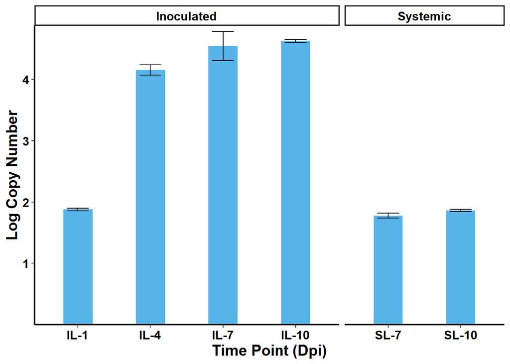

```r
CMV_1_CP_1ng <- ggplot(CMV1,aes(x =factor(Dpi,levels=c("IL-1", "IL-4", "IL-7", "IL-10","SL-7", "SL-10")), y = avg.virus)) +
  stat_summary(fun=mean,geom="bar", position = position_dodge(width = 0.3), width = 0.4, fill="#56B4E9") +
   geom_errorbar(aes(ymin = avg.virus - se,
                    ymax = avg.virus + se),
                width = 0.3,
                position = position_dodge(width = 0.3)) +
  labs(x = "Time Point (Dpi)", y = "Log Copy Number") +
  theme_classic() +
  theme(plot.title = element_text(hjust = 0.5),
        strip.text = element_text(face = "bold", size = 12, color = "black"),
        legend.position = "none",
        axis.text.x = element_text(color = "black", face="bold", size=12),   # X-axis text color
        axis.text.y = element_text(color = "black", face="bold", size=12),   # Y-axis text color
        axis.title.x = element_text(color = "black", face="bold", size=15),  # X-axis label color
        axis.title.y = element_text(color = "black", face="bold", size=15),  # Y-axis label color
        axis.line = element_line(color = "black", size=0.75)      # Axis lines color
  ) +
  scale_y_continuous(
    expand = expansion(mult = c(0, 0.02)), breaks = seq(1, 9, by = 1)  # This removes padding at the bottom of the plot
  )+
   scale_x_discrete(drop = TRUE) +
  facet_grid(~Leaf_sample, scale="free_x", space="free_x")# Sets y-axis limits but removes points outside 0-8

CMV_1_CP_1ng
```

# **Supplementary Second trial**

## Load the data

```r
rep2_CP_1ng <-read.csv("Data-obj1-New/Nb_CMV_2nd_CP_1ng.csv", header=T)
head(rep2_CP_1ng)  # View the first few rows
```

```
##    Dpi Rep    Cq
## 1 IL-1   1 27.04
## 2 IL-1   2 27.04
## 3 IL-1   3 27.01
## 4 IL-4   1 21.50
## 5 IL-4   2 21.28
## 6 IL-4   3 20.89
```

```r
str(rep2_CP_1ng)   # Check the structure of the data
```

```
## 'data.frame':    21 obs. of  3 variables:
##  $ Dpi: chr  "IL-1" "IL-1" "IL-1" "IL-4" ...
##  $ Rep: int  1 2 3 1 2 3 1 2 3 1 ...
##  $ Cq : num  27 27 27 21.5 21.3 ...
```

```r
summary(rep2_CP_1ng) # Quick statistical summary
```

```
##      Dpi                 Rep          Cq
##  Length:21          Min.   :1   Min.   :19.95
##  Class :character   1st Qu.:1   1st Qu.:20.89
##  Mode  :character   Median :2   Median :21.28
##                     Mean   :2   Mean   :23.59
##                     3rd Qu.:3   3rd Qu.:27.01
##                     Max.   :3   Max.   :33.85
```

###Make the factor variable

```r
rep2_CP_1ng$Dpi<-as.factor(rep2_CP_1ng$Dpi)
```

## Viral load

##Calculate the ViralLoad using the regression equation derived by (Feng , J.L et al., 2006 ) and log transform for normality.

[Feng, J.L et al., 2006](https://academic.oup.com/abbs/article/38/10/669/217)

```r
rep2_CP_1ng<-rep2_CP_1ng %>%
mutate (ViralLoad=((10^((Cq-37.416)/-3.353)))) %>% ##added a new column and named ViralLoad
mutate(logViralLoad=log10(ViralLoad)) %>%
  filter(Dpi!="SL-14")##added a new column and named logViralLoad
```

##Classify the sample collection days based on leaf

```r
rep2_CP_1ng$Leaf_sample<- ifelse(
  grepl("^IL", rep2_CP_1ng$Dpi), "Inoculated",  # Matches Dpi values starting with IL
  ifelse(grepl("^SL", rep2_CP_1ng$Dpi), "Systemic", NA)
)
```

##Data summarization

```r
CMV2 <- rep2_CP_1ng %>%  # Start with the dataset `rep2_CP_1ng` and pipe (%>%) it into the next operations
  group_by(Dpi, Leaf_sample) %>%   # Group the data by treatment type and days post-inoculation (Dpi)
  dplyr::summarize(
    avg.virus= mean(logViralLoad, na.rm=TRUE),
    n=n(),
    se = sd(logViralLoad)/sqrt(n)) # join the significant letters with the PVY1 data frame.
```

[output not shown]

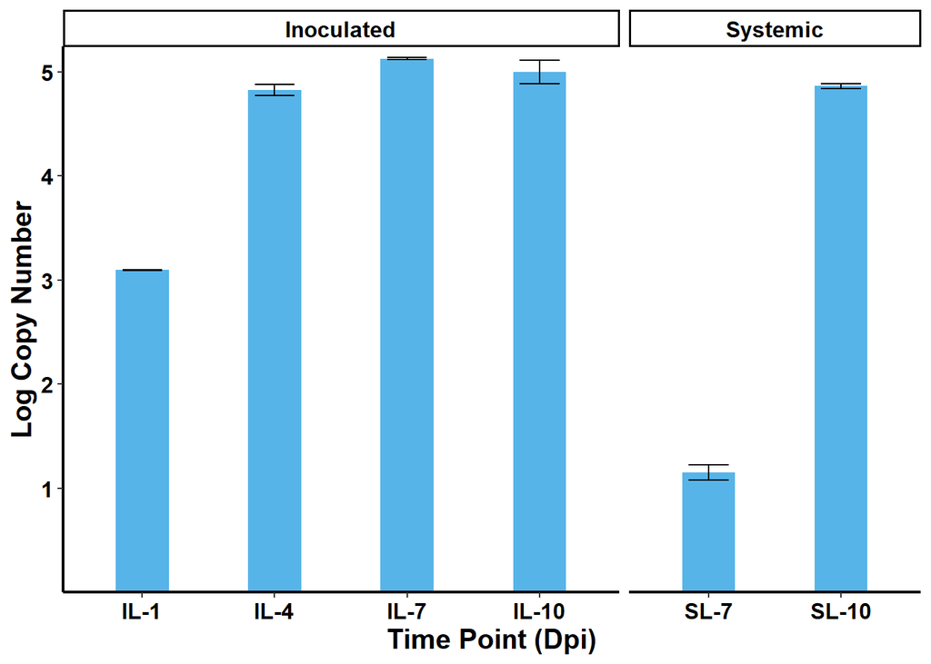

```r
CMV_2_CP_1ng <- ggplot(CMV2,aes(x =factor(Dpi,levels=c("IL-1", "IL-4", "IL-7", "IL-10","SL-7", "SL-10")), y = avg.virus)) +
  stat_summary(fun=mean,geom="bar", position = position_dodge(width = 0.3), width = 0.4, fill="#56B4E9") +
   geom_errorbar(aes(ymin = avg.virus - se,
                    ymax = avg.virus + se),
                width = 0.3,
                position = position_dodge(width = 0.3)) +
  labs(x = "Time Point (Dpi)", y = "Log Copy Number") +
  theme_classic() +
  theme(plot.title = element_text(hjust = 0.5),
        strip.text = element_text(face = "bold", size = 12, color = "black"),
        legend.position = "none",
        axis.text.x = element_text(color = "black", face="bold", size=12),   # X-axis text color
        axis.text.y = element_text(color = "black", face="bold", size=12),   # Y-axis text color
        axis.title.x = element_text(color = "black", face="bold", size=15),  # X-axis label color
        axis.title.y = element_text(color = "black", face="bold", size=15),  # Y-axis label color
        axis.line = element_line(color = "black", size=0.75)      # Axis lines color
  ) +
  scale_y_continuous(
    expand = expansion(mult = c(0, 0.02)), breaks = seq(1, 9, by = 1)  # This removes padding at the bottom of the plot
  )+
   scale_x_discrete(drop = TRUE) +
  facet_grid(~Leaf_sample, scale="free_x", space="free_x")# Sets y-axis limits but removes points outside 0-8

CMV_2_CP_1ng
```

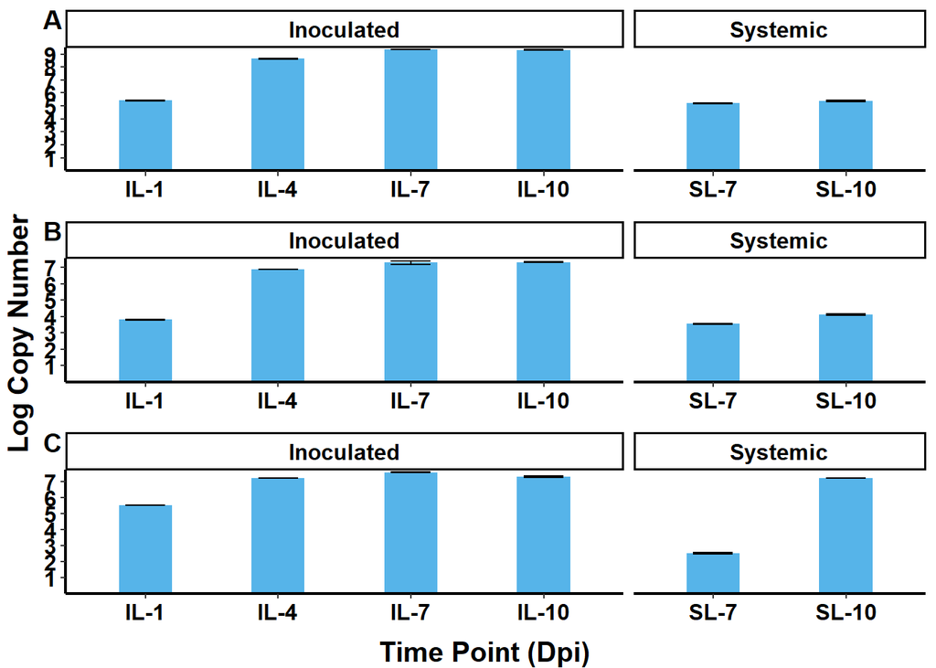

```r
# Remove axis titles
CMV_1_CP_10ng <- CMV_1_CP_10ng +
  labs(x = NULL, y = NULL) + # Remove x and y labels
  theme(axis.title = element_blank())

CMV_1_CP_1ng <- CMV_1_CP_1ng +
  labs(x = NULL, y = NULL) +
  theme(axis.title = element_blank())

CMV_2_CP_1ng <- CMV_2_CP_1ng +
  labs(x = NULL, y = NULL) +
  theme(axis.title = element_blank())
# Combine the three modified plots into one figure
combined_plot_CP <- ggarrange(
  CMV_1_CP_10ng,
  CMV_1_CP_1ng,
  CMV_2_CP_1ng,
  ncol = 1,
  labels = c("A", "B", "C"),
  align = "v"      # vertically align plots
)

# Add shared axis titles
combined_plot_CP_annotated <- annotate_figure(
  combined_plot_RNA3,
  bottom = text_grob("Time Point (Dpi)", size = 15, face="bold"),
  left = text_grob("Log Copy Number", rot = 90, size = 15, face="bold")
)
combined_plot_CP_annotated
```